# Initial NLP Work on Film Scripts

Author

Mick Cooney mickcooney@gmail.com

Published

January 16, 2023

In this workbook we perform the initial NLP pre-processing and simple explorations and visualisations of the data.

# 1 Load Data

```r
films_master_tbl <- read_rds("data/films_master_tbl.rds")

films_master_tbl |> glimpse()
```

```
Rows: 48
Columns: 9
$ film_title      <chr> "12 Years a Slave", "2001 A Space Odyssey", "Airplane"…
$ release_year    <int> 2013, 1968, 1977, 1979, 1997, 1955, 1974, 1990, 2012, …
$ genre           <chr> "Drama", "Science Fiction", "Comedy", "War", "Comedy",…
$ title_cleaned   <chr> "12_years_a_slave", "2001_a_space_odyssey", "airplane"…
$ cached_htmlfile <glue> "scraped_files/scraped_raw/scraped_raw_12_years_a_sla…
$ script_txtfile  <glue> "scraped_files/scraped_raw/script_12_years_a_slave.tx…
$ cleaned_txtfile <glue> "scraped_files/cleaned_script/cleanedscript_12_years_…
$ flag_cleaned    <lgl> FALSE, FALSE, FALSE, FALSE, TRUE, FALSE, FALSE, FALSE,…
$ parsed_file     <glue> "data/parsed_scripts/parsedscript_12_years_a_slave.rd…
```

The parsed data is stored in the file listed in the column `parsed_file` and contains to separate tibbles, one with the detailed parsing of the script and the second which aggregates all the text for both scene directions and dialogue.

Also, a number of film scripts have not parsed properly, so we also want to create a list of those films and exclude them from the analysis.

We may go back later to improve the parsing and if this happens we will updated this list.

```r
films_exclude_tbl <- c(
    "12_years_a_slave", "2001_a_space_odyssey", "django_unchained",
    "gran_torino", "leaving_las_vegas", "lock_stock_and_two_smoking_barrels",
    "moneyball", "office_space", "star_wars_return_of_the_jedi",
    "the_green_mile"
    ) |>
  enframe(name = NULL, value = "title_cleaned")

films_exclude_tbl |> glimpse()
```

```
Rows: 10
Columns: 1
$ title_cleaned <chr> "12_years_a_slave", "2001_a_space_odyssey", "django_unch…
```

```r
films_parsed_tbl <- films_master_tbl |>
  anti_join(films_exclude_tbl, by = "title_cleaned") |>
  mutate(
    parsed_data = map(parsed_file, read_rds)
    ) |>
  unnest(parsed_data) |>
  select(
    film_title, release_year, genre, title_cleaned, parsing_detailed,
    parsing_aggregated
    )

films_parsed_tbl |> glimpse()
```

```
Rows: 38
Columns: 6
$ film_title         <chr> "Airplane", "Apocalypse Now", "Austin Powers - Inte…
$ release_year       <int> 1977, 1979, 1997, 1955, 1974, 1990, 1988, 1997, 201…
$ genre              <chr> "Comedy", "War", "Comedy", "Western", "Crime", "Wes…
$ title_cleaned      <chr> "airplane", "apocalypse_now", "austin_powers_intern…
$ parsing_detailed   <list> [<tbl_df[5646 x 13]>], [<tbl_df[8014 x 13]>], [<tb…
$ parsing_aggregated <list> [<tbl_df[1245 x 4]>], [<tbl_df[1388 x 4]>], [<tbl_…
```

# 2 Initial NLP Processing

We now want to perform some very basic NLP processing such as *tokenisation*.

Once we have tokenised the script, we also remove “stop words” - that is, common words that do not convey meaning, such as “and”, “to”, “the” and so on.

```r
data(stop_words)

films_tokens_tbl <- films_parsed_tbl |>
  mutate(
    wordtoken_data = map(
      parsing_aggregated, unnest_tokens,
      output = word, input = full_text
      ),
    ngramtoken_data = map(
      parsing_aggregated, unnest_tokens,
      output = word, input = full_text, token = "ngrams", n = 2, n_min = 1
      )
    ) |>
  select(-parsing_detailed, -parsing_aggregated)

films_wordtoken_unstopped_tbl <- films_tokens_tbl |>
  select(-ngramtoken_data) |>
  unnest(wordtoken_data)

films_wordtoken_tbl <- films_wordtoken_unstopped_tbl |>
  anti_join(stop_words, by = "word")
```

## 2.1 Show Initial Wordclouds

We now want to create some word clouds as a quick initial visualisation of the data.

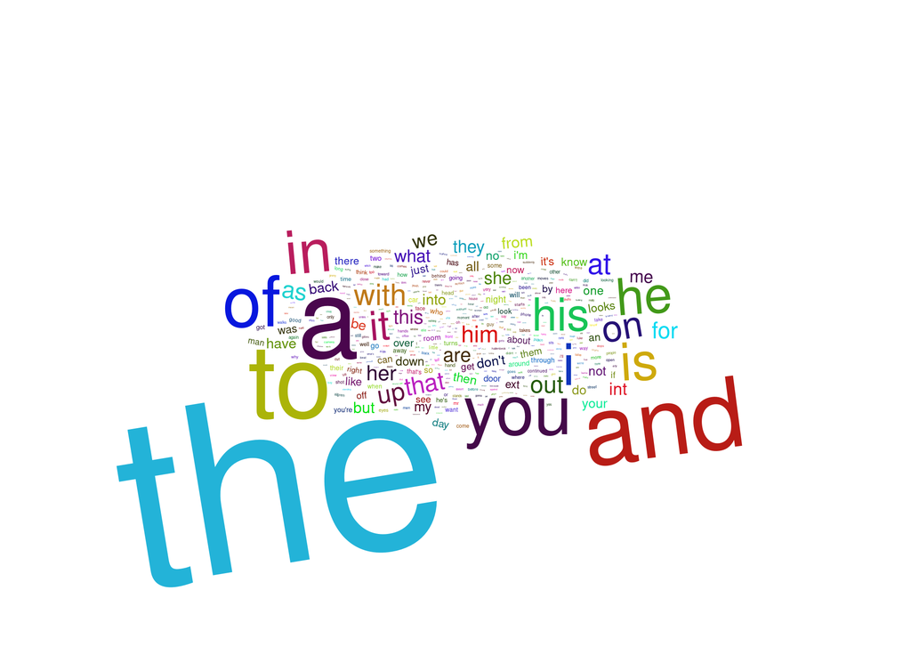

```r
plot_unstopped_tbl <- films_wordtoken_unstopped_tbl |>
  count(word) |>
  slice_max(order_by = n, n = 500)

ggwordcloud2(plot_unstopped_tbl, size = 4, seed = 421)
```

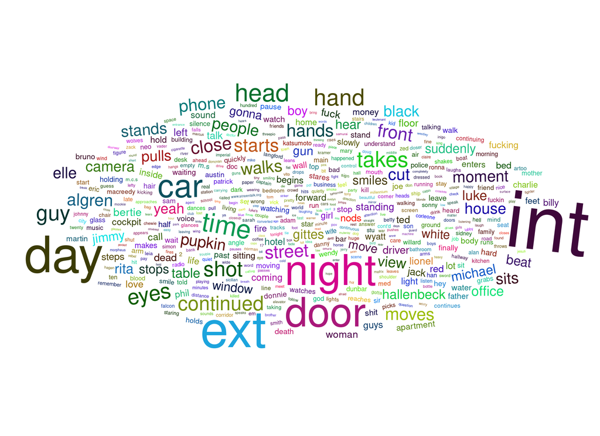

## 2.2 Word-stemming

We also want to look at stemming our words.

```r
films_stems_tbl <- films_wordtoken_tbl |>
  mutate(
    snowball_stem = wordStem(word),
    hunspell_stem = hunspell_stem(word)
    )

films_stems_tbl |> glimpse()
```

```
Rows: 368,978
Columns: 10
$ film_title    <chr> "Airplane", "Airplane", "Airplane", "Airplane", "Airplan…
$ release_year  <int> 1977, 1977, 1977, 1977, 1977, 1977, 1977, 1977, 1977, 19…
$ genre         <chr> "Comedy", "Comedy", "Comedy", "Comedy", "Comedy", "Comed…
$ title_cleaned <chr> "airplane", "airplane", "airplane", "airplane", "airplan…
$ section_title <chr> "Written by", "Written by", "Written by", "Written by", …
$ grouping_id   <int> 2, 2, 2, 2, 2, 2, 6, 6, 6, 6, 6, 6, 6, 6, 6, 6, 6, 6, 6,…
$ flag_dialogue <lgl> TRUE, TRUE, TRUE, TRUE, TRUE, TRUE, FALSE, FALSE, FALSE,…
$ word          <chr> "jim", "abrahams", "david", "zucker", "jerry", "zucker",…
$ snowball_stem <chr> "jim", "abraham", "david", "zucker", "jerri", "zucker", …
$ hunspell_stem <list> <>, <>, <>, <>, <>, <>, "fade", "ext", "sky", "cloud", …
```

We also create a word cloud of this stemmed data

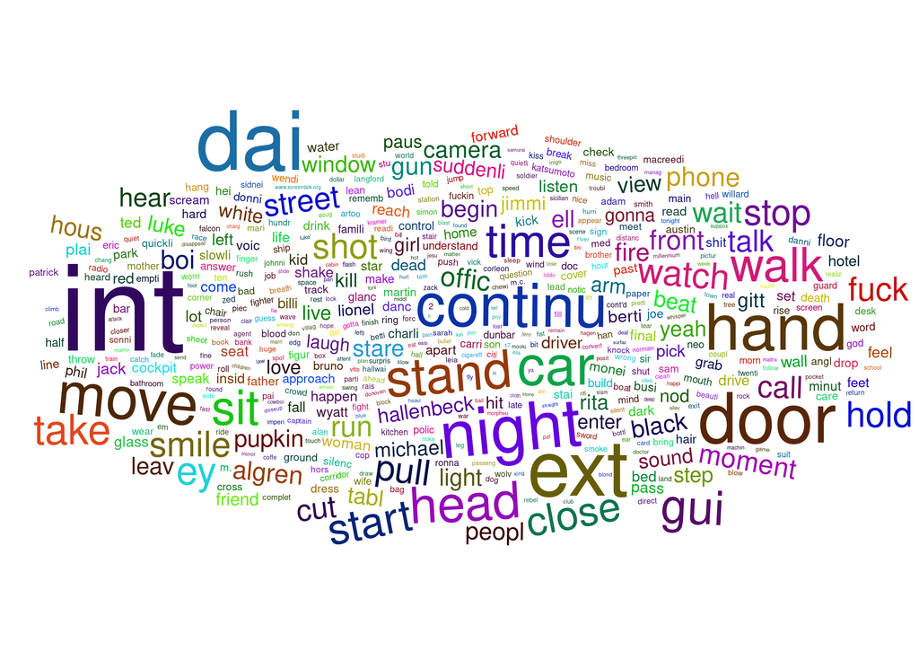

```r
plot_stemmed_tbl <- films_stems_tbl |>
  count(word = snowball_stem) |>
  slice_max(order_by = n, n = 500)

ggwordcloud2(plot_stemmed_tbl, size = 2, seed = 422)
```